# ARC workshops

[figure not shown]

```r
knitr::opts_chunk$set(echo = FALSE, warning = FALSE, message = FALSE, error = TRUE)
```

**22 people participated:**

Jan K., Kyanoush, Thorsten Pachur, Anastasia Kozyreva, Nika, Tim Pleskac, Charley, Mehdi, Stefan Herzog, Christin, Wouter, Simon, Jayles, Antonio, Philipp, Christina, Susannah, Florian, Lou, Lucas, Nikita, Alan

**If you like, please describe in 2-3 sentences what your ideal next workshop would look like (topic, format etc.)**

Depends. For a “I learned something at the workshop”: Multiple shortish (~45min) workshops. Introduction with slides, switch to hands on. Ideally more than one instructor (or at least 1 per 6-7 participants). For a “this is interesting, let me have a closer look alone”: One workshop with more theory and some pratical elements.,

(see below),

Personally, i would be interested in workshops on academic writing and presentation skills, possibly also popular science writing.,

My ideal workshop is composed of a set of 45 minute sessions where 1 or 2 core ideas are presented in each session. The session gives hands on practice. And each session cumulatively builds on each other (but also can stand on its own). ,

Learning about new computational or mathematical methods. Short, interactive, and makes a complex topic very clear. Ideally, only covers the basic understanding, while the details can be filled in individually after the workshop,

Hands-on (laptops) workshop on using R’s brms package for Bayesian inference. I’d be especially interested in how to estimate mixed-effects GLMs (e.g., signal detection models implemented as probit regression models) and how to estimate (simple) models involving more than one equation.,

A workshop about formr, and/or open science related tools. ,

Data analysis Bayes. Perparing Code for using multiple cores on the Server. Useful tools for infering on interindividual differencies.,

Learning is key. Not necessarily to choose one technology and diminish another. Let’s create an environment to share knowledge and to inspire each other so that everyone can develop in the way he / she think it’s best.,

short presentation then hands-on work,

I could REALLY have done with a LaTeX workshop before I had to start working with it. Now it’s too late!

Would be interested in learning about language recognition software (the practicalities). It would also be interesting from an editing point of view to see whether texts produced by dictation (e.g., using Dragon Naturally Speaking) are any more accessible/readable/effective than texts produced by typing. Or the contrary … ,

Bayesian hierarchical modelling - oh now I see it’s in the list! (so that’s my #1). Brief conceptual intro and then a hands-on workshop analysing data. (note, Wouter, Simon and I plan to start reading the Lee and Wagenmakers book on Bayesian modelling as we need it in Wouter’s larger project from which Simon and I are paid - we might want to coordinate this book reading with you?),

A workshop on scientific writing would be great.

**What are some topics about which you know something that others might find interesting or useful?**

Qualtrics (experimental design, Javascript, embedded variables) - Jan K.,

Robustness analyses in computational modeling; Gaussian processes; entropy models of information search - Charley,

workshop on how to use git/arc-git using machine learning algorithms with R’s caret package - Stefan Herzog,

- Mattermost slash commands and integrations. Let’s g(r)o(w) from a chat application to ChatOps universe - Antonio,

meta-analyses; violine plots (a.k.a bean plots) - Philipp,

As Deb mentioned, we will be offering writing workshops when we’ve got Taming Uncertainty done and dusted. Would be very interested to hear what kind of writing workshops people would be interested in/the kind of formats they are requesting. - Susannah,

running *interactive* (multi-agent games with live interactions) experiments online using Amazon Mechanical Turk.

experimental design - Lucas,

- - Alan

## Items

### formats

#### Distribution

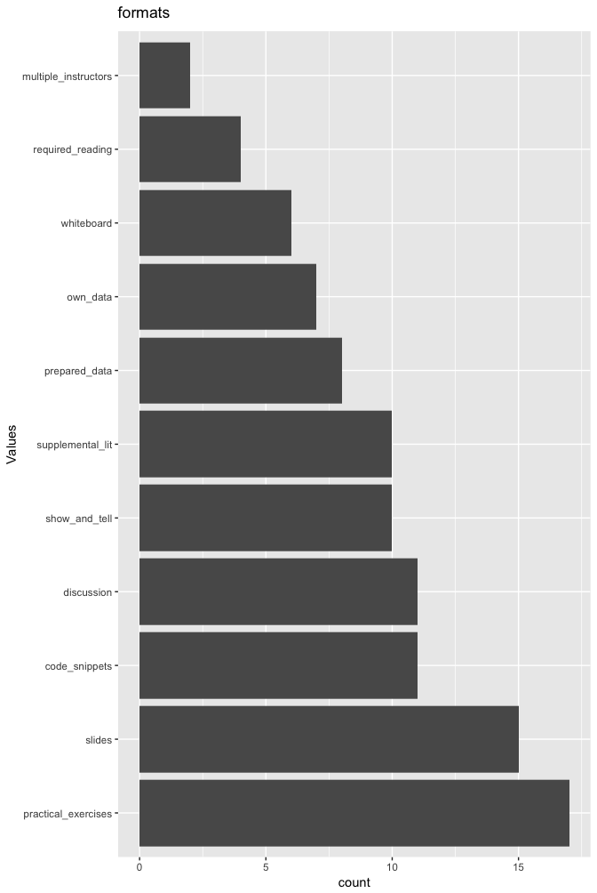

0 missings.

#### Summary statistics

Table continues below

| name | data_type | ordered | missing | complete | n | n_unique |
| --- | --- | --- | --- | --- | --- | --- |
| formats | factor | FALSE | 0 | 101 | 101 | 11 |

Table continues below

| top_counts | V1 | V2 | V3 |
| --- | --- | --- | --- |
| pra: 17, sli: 15, cod: 11, dis: 11 | practical_exercises | slides | code_snippets |

Table continues below

| V4 | V5 | V6 | V7 | V8 |
| --- | --- | --- | --- | --- |
| discussion | show_and_tell | supplemental_lit | prepared_data | own_data |

| V9 | V10 | V11 |
| --- | --- | --- |
| whiteboard | required_reading | multiple_instructors |

#### Value labels

- | show_and_tell |
  | --- |
  | show_and_tell |

- | whiteboard |
  | --- |
  | whiteboard |

- | supplemental_lit |
  | --- |
  | supplemental_lit |

- | discussion |
  | --- |
  | discussion |

- | practical_exercises |
  | --- |
  | practical_exercises |

- | prepared_data |
  | --- |
  | prepared_data |

- | required_reading |
  | --- |
  | required_reading |

- | slides |
  | --- |
  | slides |

- | code_snippets |
  | --- |
  | code_snippets |

- | own_data |
  | --- |
  | own_data |

- | multiple_instructors |
  | --- |
  | multiple_instructors |

```
## [1] ""
```

```
## [1] ""
```

## Items

### topics_ruben

#### Distribution

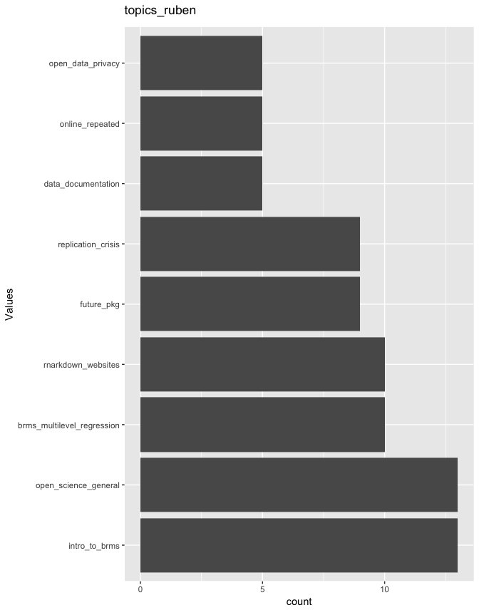

0 missings.

#### Summary statistics

Table continues below

| name | data_type | ordered | missing | complete | n | n_unique |
| --- | --- | --- | --- | --- | --- | --- |
| topics_ruben | factor | FALSE | 0 | 79 | 79 | 9 |

Table continues below

| top_counts | V1 | V2 |
| --- | --- | --- |
| int: 13, ope: 13, brm: 10, rna: 10 | intro_to_brms | open_science_general |

Table continues below

| V3 | V4 | V5 |
| --- | --- | --- |
| brms_multilevel_regression | rnarkdown_websites | future_pkg |

| V6 | V7 | V8 | V9 |
| --- | --- | --- | --- |
| replication_crisis | data_documentation | online_repeated | open_data_privacy |

#### Value labels

- | open_data_privacy |
  | --- |
  | open_data_privacy |

- | open_science_general |
  | --- |
  | open_science_general |

- | intro_to_brms |
  | --- |
  | intro_to_brms |

- | future_pkg |
  | --- |
  | future_pkg |

- | replication_crisis |
  | --- |
  | replication_crisis |

- | brms_multilevel_regression |
  | --- |
  | brms_multilevel_regression |

- | rnarkdown_websites |
  | --- |
  | rnarkdown_websites |

- | online_repeated |
  | --- |
  | online_repeated |

- | data_documentation |
  | --- |
  | data_documentation |

```
## [1] ""
```

```
## [1] ""
```

## Items

### topics_you_need

#### Distribution

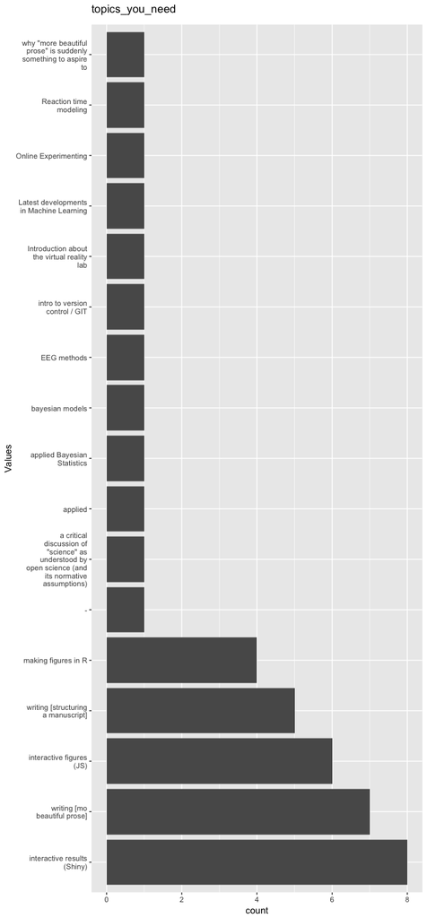

0 missings.

#### Summary statistics

Table continues below

| name | data_type | ordered | missing | complete | n | n_unique |
| --- | --- | --- | --- | --- | --- | --- |
| topics_you_need | factor | FALSE | 0 | 42 | 42 | 17 |

Table continues below

| top_counts | V1 |
| --- | --- |
| int: 8, wri: 7, int: 6, wri: 5 | interactive results (Shiny) |

Table continues below

| V2 | V3 |
| --- | --- |
| writing [mo beautiful prose] | interactive figures (JS) |

Table continues below

| V4 | V5 | V6 | V7 |
| --- | --- | --- | --- |
| writing [structuring a manuscript] | making figures in R | - | a critical discussion of “science” as understood by open science (and its normative assumptions) |

Table continues below

| V8 | V9 | V10 | V11 |
| --- | --- | --- | --- |
| applied | applied Bayesian Statistics | bayesian models | EEG methods |

Table continues below

| V12 | V13 |
| --- | --- |
| intro to version control / GIT | Introduction about the virtual reality lab |

Table continues below

| V14 | V15 | V16 |
| --- | --- | --- |
| Latest developments in Machine Learning | Online Experimenting | Reaction time modeling |

| V17 |
| --- |
| why “more beautiful prose” is suddenly something to aspire to |

#### Value labels

- | a critical discussion of “science” as understood by open science (and its normative assumptions) |
  | --- |
  | a critical discussion of “science” as understood by open science (and its normative assumptions) |

- | writing [structuring a manuscript] |
  | --- |
  | writing [structuring a manuscript] |

- | writing [mo beautiful prose] |
  | --- |
  | writing [mo beautiful prose] |

- | interactive results (Shiny) |
  | --- |
  | interactive results (Shiny) |

- | interactive figures (JS) |
  | --- |
  | interactive figures (JS) |

- | intro to version control / GIT |
  | --- |
  | intro to version control / GIT |

- | making figures in R |
  | --- |
  | making figures in R |

- | Reaction time modeling |
  | --- |
  | Reaction time modeling |

- | EEG methods |
  | --- |
  | EEG methods |

- | Latest developments in Machine Learning |
  | --- |
  | Latest developments in Machine Learning |

- | Introduction about the virtual reality lab |
  | --- |
  | Introduction about the virtual reality lab |

- | Online Experimenting |
  | --- |
  | Online Experimenting |

- | bayesian models |
  | --- |
  | bayesian models |

- | why “more beautiful prose” is suddenly something to aspire to |
  | --- |
  | why “more beautiful prose” is suddenly something to aspire to |

- | applied |
  | --- |
  | applied |

- | applied Bayesian Statistics |
  | --- |
  | applied Bayesian Statistics |

```
## [1] ""
```

```
## [1] ""
```

### Survey overview

22 completed rows, 22 who entered any information, 0 only viewed the first page. There are 0 expired rows (people who did not finish filling out in the requested time frame). In total, there are 22 rows including unfinished and expired rows.

There were 22 unique participants, of which 22 finished filling out at least one survey.

This survey was not repeated.

The first session started on 2018-03-02 11:17:16, the last session on 2018-03-15 17:51:17.

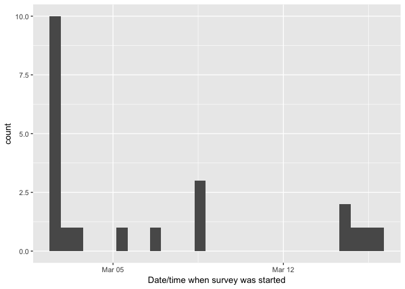

People took on average 1270.25 minutes (median 8.57) to answer the survey.

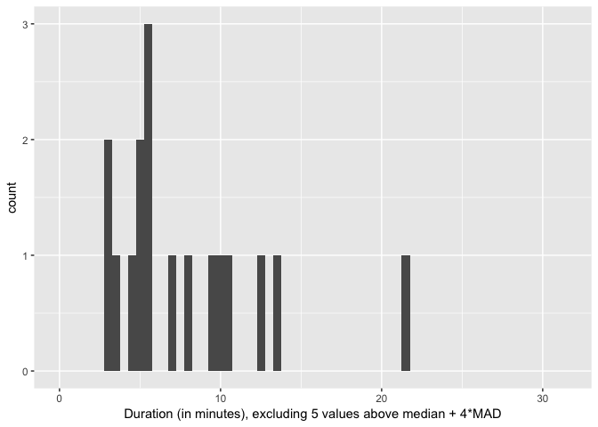

## Items

### time_frame

What kind of time frame would you like best (more complex topics would be broken up across subsequent sessions)?

#### Distribution

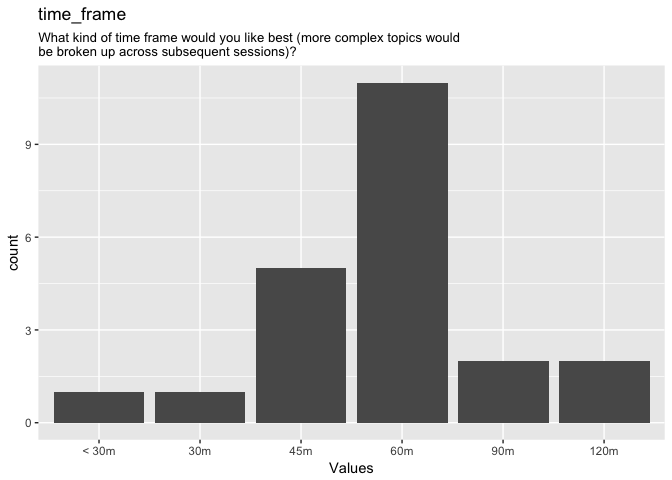

0 missings.

#### Summary statistics

Table continues below

| name | label | type | data_type | ordered |
| --- | --- | --- | --- | --- |
| time_frame | What kind of time frame would you like best (more complex topics would be broken up across subsequent sessions)? | mc | labelled | FALSE |

Table continues below

| value_labels | showif | item_order |
| --- | --- | --- |
| < 30m=1,30m=2,45m=3,60m=4,90m=5,120m=6,> 120m=7 |  | 5 |

| class | missing | complete | n | n_unique | top_counts |
| --- | --- | --- | --- | --- | --- |
| mc_vertical left500 | 0 | 22 | 22 | 6 | 4: 11, 3: 5, 5: 2, 6: 2 |

#### Item

Table continues below

| type | type_options | name | label | optional |
| --- | --- | --- | --- | --- |
| mc | NULL | time_frame | What kind of time frame would you like best (more complex topics would be broken up across subsequent sessions)? | NULL |

| class | showif | value | block_order | item_order |
| --- | --- | --- | --- | --- |
| mc_vertical left500 |  | NULL | NULL | 5 |

#### Value labels

- **< 30m**: *1*
- **30m**: *2*
- **45m**: *3*
- **60m**: *4*
- **90m**: *5*
- **120m**: *6*
- **> 120m**: *7*

```
## [1] ""
```

```
## [1] ""
```